# Attrition Prediction

# ROC Analysis

```r
# Load required libraries
library(caret)
library(pROC)
# Encode categorical variables using one-hot encoding
talent_data_dummy <- dummyVars(~ Age + Department + MonthlyIncome + JobRole + JobSatisfaction, data = talent_data.up)
talent_data_encoded <- data.frame(predict(talent_data_dummy, newdata = talent_data.up))
talent_data_encoded$Attrition <- talent_data.up$Attrition

# Split the dataset into training and testing sets
set.seed(42)
trainIndex <- createDataPartition(talent_data_encoded$Attrition, p = 0.8, list = FALSE, times = 1)
train_set <- talent_data_encoded[trainIndex,]
test_set <- talent_data_encoded[-trainIndex,]

# Create a logistic regression model
model <- glm(Attrition ~ ., data = train_set, family = "binomial")

# Make predictions
predictions <- predict(model, test_set, type = "response")
predicted_classes <- ifelse(predictions > 0.5, 1, 0)

# Evaluate model performance
cm <- confusionMatrix(factor(predicted_classes), factor(test_set$Attrition))
print(cm)
```

```
## Confusion Matrix and Statistics
##
##           Reference
## Prediction   0   1
##          0  95  42
##          1  51 104
##
##                Accuracy : 0.6815
##                  95% CI : (0.6247, 0.7346)
##     No Information Rate : 0.5
##     P-Value [Acc > NIR] : 2.61e-10
##
##                   Kappa : 0.363
##
##  Mcnemar's Test P-Value : 0.4068
##
##             Sensitivity : 0.6507
##             Specificity : 0.7123
##          Pos Pred Value : 0.6934
##          Neg Pred Value : 0.6710
##              Prevalence : 0.5000
##          Detection Rate : 0.3253
##    Detection Prevalence : 0.4692
##       Balanced Accuracy : 0.6815
##
##        'Positive' Class : 0
##
```

```r
# Calculate the ROC curve and AUC
roc_obj <- roc(test_set$Attrition, predictions)
# Print AUC
cat("AUC:", auc(roc_obj), "\n")
```

```
## AUC: 0.7331582
```

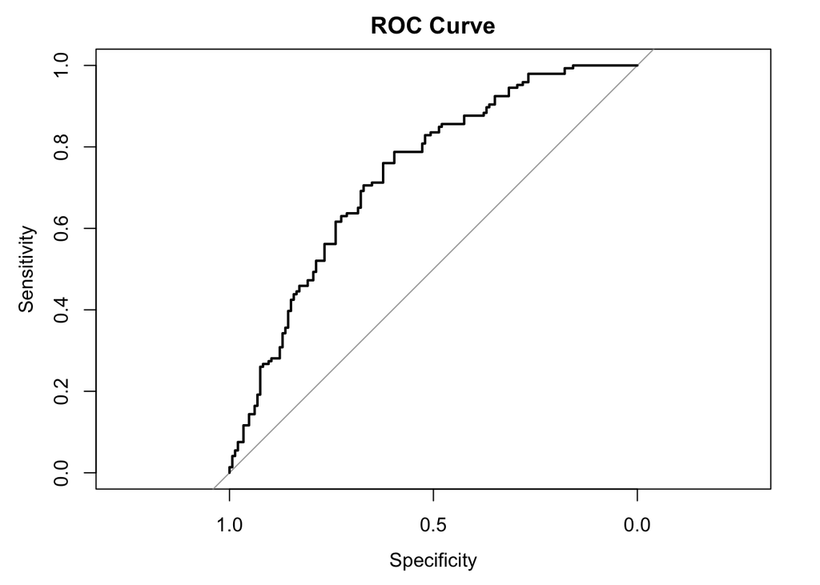

```r
# Plot the ROC curve
plot(roc_obj, main = "ROC Curve")
```

In this analysis, the goal is to create a logistic regression model to predict attrition using the given dataset. After encoding categorical variables with one-hot encoding, the dataset is split into training and testing sets with 80% of the data for training and the remaining 20% for testing.

The logistic regression model is fit using the training set, and predictions are made on the test set. The model’s performance is evaluated using a confusion matrix, which shows the accuracy of the model to be 68.15%, with a 95% confidence interval of (62.47%, 73.46%). The No Information Rate (NIR) is 0.5, and the p-value indicates that the model’s accuracy is significantly better than the NIR. The kappa statistic, which measures the agreement between predictions and true values, is 0.363.

Mcnemar’s test p-value is 0.4068, which does not indicate a significant difference between the number of false positives and false negatives. The model’s sensitivity is 65.07%, and specificity is 71.23%. The positive predictive value (PPV) is 69.34%, and the negative predictive value (NPV) is 67.10%. The prevalence of attrition in the test set is 50%.

# lasso model

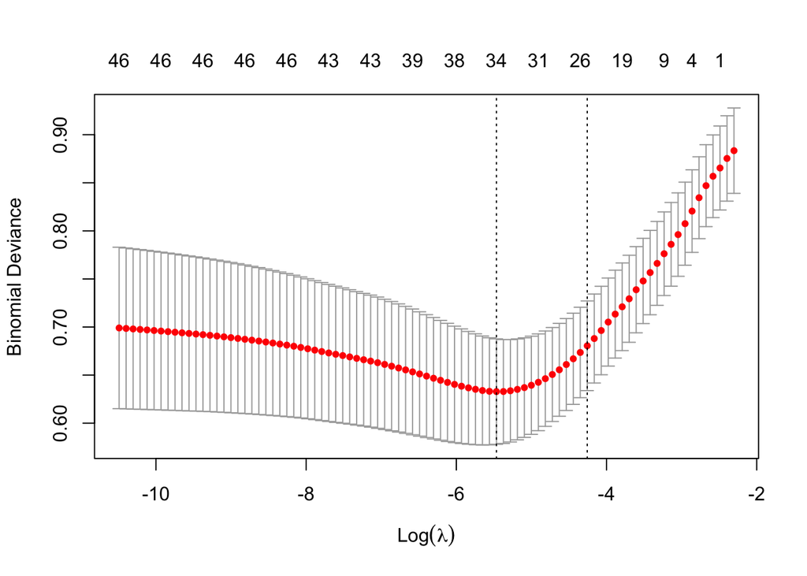

```r
# Convert character columns to factors
talent_data[] <- lapply(talent_data, function(x) {
  if (is.character(x)) as.factor(x) else x
})

# Remove columns with only one level
talent_data <- talent_data %>% select_if(~ !is.factor(.) || nlevels(.) > 1)

# Create a design matrix with dummy variables
x <- model.matrix(Attrition ~ . - 1, data = talent_data)
y <- as.matrix(talent_data$Attrition)

# Perform Lasso regression
lasso_model <- cv.glmnet(x, y, alpha = 1, family = "binomial")
plot(lasso_model)
```

```r
coef(lasso_model, s = "lambda.min")
```

```
## 50 x 1 sparse Matrix of class "dgCMatrix"
##                                             s1
## (Intercept)                       3.213901e+00
## ID                                1.513935e-04
## Age                              -2.718152e-02
## BusinessTravelNon-Travel         -5.040408e-01
## BusinessTravelTravel_Frequently   5.308863e-01
## BusinessTravelTravel_Rarely       .
## DailyRate                        -1.638003e-04
## DepartmentResearch & Development -2.964594e-01
## DepartmentSales                   .
## DistanceFromHome                  3.603028e-02
## Education                         .
## EducationFieldLife Sciences       .
## EducationFieldMarketing           .
## EducationFieldMedical            -6.222536e-03
## EducationFieldOther               .
## EducationFieldTechnical Degree    3.438922e-01
## EmployeeCount                     .
## EmployeeNumber                   -6.784480e-05
## EnvironmentSatisfaction          -2.373449e-01
## GenderMale                        1.147039e-01
## HourlyRate                        6.851133e-03
## JobInvolvement                   -7.009002e-01
## JobLevel                          .
## JobRoleHuman Resources            4.913337e-01
## JobRoleLaboratory Technician      4.193994e-01
## JobRoleManager                    .
## JobRoleManufacturing Director    -1.346675e+00
## JobRoleResearch Director         -9.658139e-01
## JobRoleResearch Scientist         .
## JobRoleSales Executive            .
## JobRoleSales Representative       1.087025e+00
## JobSatisfaction                  -3.802385e-01
## MaritalStatusMarried              4.407980e-01
## MaritalStatusSingle               1.125680e+00
## MonthlyIncome                     .
## MonthlyRate                      -9.407643e-06
## NumCompaniesWorked                1.646025e-01
## OverTimeYes                       1.679484e+00
## PercentSalaryHike                 .
## PerformanceRating                 1.982323e-02
## RelationshipSatisfaction         -1.712535e-01
## StandardHours                     .
## StockOptionLevel                 -1.201262e-01
## TotalWorkingYears                -5.221784e-02
## TrainingTimesLastYear            -2.069358e-01
## WorkLifeBalance                  -4.179496e-01
## YearsAtCompany                    .
## YearsInCurrentRole               -6.489862e-02
## YearsSinceLastPromotion           1.858612e-01
## YearsWithCurrManager             -7.766915e-02
```

Based on the LASSO model we’ve just run, we can interpret the non-zero coefficients as the most important features for predicting attrition. Here is a summary of the important features and their coefficients:

```r
# Extract the coefficients at lambda.min
lasso_coefs <- coef(lasso_model, s = "lambda.min")

# Find the non-zero coefficients (excluding intercept)
non_zero_indices <- which(lasso_coefs[-1, 1] != 0)

# Extract the important features and their coefficients
important_features <- lasso_coefs[non_zero_indices + 1, , drop = FALSE]

# Display the important features and their coefficients
print(important_features)
```

```
## 34 x 1 sparse Matrix of class "dgCMatrix"
##                                             s1
## ID                                1.513935e-04
## Age                              -2.718152e-02
## BusinessTravelNon-Travel         -5.040408e-01
## BusinessTravelTravel_Frequently   5.308863e-01
## DailyRate                        -1.638003e-04
## DepartmentResearch & Development -2.964594e-01
## DistanceFromHome                  3.603028e-02
## EducationFieldMedical            -6.222536e-03
## EducationFieldTechnical Degree    3.438922e-01
## EmployeeNumber                   -6.784480e-05
## EnvironmentSatisfaction          -2.373449e-01
## GenderMale                        1.147039e-01
## HourlyRate                        6.851133e-03
## JobInvolvement                   -7.009002e-01
## JobRoleHuman Resources            4.913337e-01
## JobRoleLaboratory Technician      4.193994e-01
## JobRoleManufacturing Director    -1.346675e+00
## JobRoleResearch Director         -9.658139e-01
## JobRoleSales Representative       1.087025e+00
## JobSatisfaction                  -3.802385e-01
## MaritalStatusMarried              4.407980e-01
## MaritalStatusSingle               1.125680e+00
## MonthlyRate                      -9.407643e-06
## NumCompaniesWorked                1.646025e-01
## OverTimeYes                       1.679484e+00
## PerformanceRating                 1.982323e-02
## RelationshipSatisfaction         -1.712535e-01
## StockOptionLevel                 -1.201262e-01
## TotalWorkingYears                -5.221784e-02
## TrainingTimesLastYear            -2.069358e-01
## WorkLifeBalance                  -4.179496e-01
## YearsInCurrentRole               -6.489862e-02
## YearsSinceLastPromotion           1.858612e-01
## YearsWithCurrManager             -7.766915e-02
```

These are the features we should focus on in our predictive model for employee attrition. Keep in mind that some coefficients are positive, indicating a positive relationship with attrition, while others are negative, indicating a negative relationship.